# Finding Happiness

This dataset was obtained [here](https://www.kaggle.com/unsdsn/world-happiness).

“The World Happiness Report is a landmark survey of the state of global happiness. The first report was published in 2012, the second in 2013, the third in 2015, and the fourth in the 2016 Update.” “…The report continues to gain global recognition as governments, organizations and civil society increasingly use happiness indicators to inform their policy-making decisions. Leading experts across fields – economics, psychology, survey analysis, national statistics, health, public policy and more – describe how measurements of well-being can be used effectively to assess the progress of nations. The reports review the state of happiness in the world today and show how the new science of happiness explains personal and national variations in happiness.”

“The happiness scores and rankings use data from the Gallup World Poll. The scores are based on answers to the main life evaluation question asked in the poll. This question, known as the Cantril ladder, asks respondents to think of a ladder with the best possible life for them being a 10 and the worst possible life being a 0 and to rate their own current lives on that scale. The scores are from nationally representative samples for the years 2013-2016 and use the Gallup weights to make the estimates representative. The columns following the happiness score estimate the extent to which each of six factors – economic production, social support, life expectancy, freedom, absence of corruption, and generosity – contribute to making life evaluations higher in each country than they are in Dystopia, a hypothetical country that has values equal to the world’s lowest national averages for each of the six factors. They have no impact on the total score reported for each country, but they do explain why some countries rank higher than others.”

Per [their document](http://worldhappiness.report/wp-content/uploads/sites/2/2016/03/HR-V1_web.pdf), here are the measures of each factors:

- **GDP per capita**
- **Healthy years of life expectancy**
- **Social support**  
  “If you were in trouble, do you have relatives or friends you can count on to help you whenever you need them, or not?”
- **Trust**  
  As measured by a perceived absence of corruption in government and business, perceptions of corruption are the average of binary answers to two GWP questions: “Is corruption widespread throughout the government or not” and “Is corruption widespread within businesses or not?” Where data for government corruption are missing, the perception of business corruption is used as the overall corruption-perception measure.
- **Freedom to make life decisions**  
  “Are you satisfied or dissatisfied with your freedom to choose what you do with your life?”
- **Generosity**  
  “Have you donated money to a charity in the past month?” on GDP per capita.

## Univariate Plots Section

#### Taking a peek

```
## Observations: 157
## Variables: 13
## $ Country                       <fct> Denmark, Switzerland, Iceland, N...
## $ Region                        <fct> Western Europe, Western Europe, ...
## $ Happiness.Rank                <int> 1, 2, 3, 4, 5, 6, 7, 8, 9, 10, 1...
## $ Happiness.Score               <dbl> 7.526, 7.509, 7.501, 7.498, 7.41...
## $ Lower.Confidence.Interval     <dbl> 7.460, 7.428, 7.333, 7.421, 7.35...
## $ Upper.Confidence.Interval     <dbl> 7.592, 7.590, 7.669, 7.575, 7.47...
## $ Economy..GDP.per.Capita.      <dbl> 1.44178, 1.52733, 1.42666, 1.577...
## $ Family                        <dbl> 1.16374, 1.14524, 1.18326, 1.126...
## $ Health..Life.Expectancy.      <dbl> 0.79504, 0.86303, 0.86733, 0.795...
## $ Freedom                       <dbl> 0.57941, 0.58557, 0.56624, 0.596...
## $ Trust..Government.Corruption. <dbl> 0.44453, 0.41203, 0.14975, 0.357...
## $ Generosity                    <dbl> 0.36171, 0.28083, 0.47678, 0.378...
## $ Dystopia.Residual             <dbl> 2.73939, 2.69463, 2.83137, 2.664...
```

#### Cleaning up a little…

First, I’m removing the periods in the column names. I’m also replacing some of the long names for clarity.

```
##  [1] "Country"                 "Region"
##  [3] "HappinessRank"           "HappinessScore"
##  [5] "LowerConfidenceInterval" "UpperConfidenceInterval"
##  [7] "GDP"                     "SocialSupport"
##  [9] "LifeExpectancy"          "Freedom"
## [11] "TrustForGovernment"      "Generosity"
## [13] "DystopiaResidual"
```

#### Summary

```
##         Country                                Region   HappinessRank
##  Afghanistan:  1   Sub-Saharan Africa             :38   Min.   :  1.00
##  Albania    :  1   Central and Eastern Europe     :29   1st Qu.: 40.00
##  Algeria    :  1   Latin America and Caribbean    :24   Median : 79.00
##  Angola     :  1   Western Europe                 :21   Mean   : 78.98
##  Argentina  :  1   Middle East and Northern Africa:19   3rd Qu.:118.00
##  Armenia    :  1   Southeastern Asia              : 9   Max.   :157.00
##  (Other)    :151   (Other)                        :17
##  HappinessScore  LowerConfidenceInterval UpperConfidenceInterval
##  Min.   :2.905   Min.   :2.732           Min.   :3.078
##  1st Qu.:4.404   1st Qu.:4.327           1st Qu.:4.465
##  Median :5.314   Median :5.237           Median :5.419
##  Mean   :5.382   Mean   :5.282           Mean   :5.482
##  3rd Qu.:6.269   3rd Qu.:6.154           3rd Qu.:6.434
##  Max.   :7.526   Max.   :7.460           Max.   :7.669
##
##       GDP         SocialSupport    LifeExpectancy      Freedom
##  Min.   :0.0000   Min.   :0.0000   Min.   :0.0000   Min.   :0.0000
##  1st Qu.:0.6702   1st Qu.:0.6418   1st Qu.:0.3829   1st Qu.:0.2575
##  Median :1.0278   Median :0.8414   Median :0.5966   Median :0.3975
##  Mean   :0.9539   Mean   :0.7936   Mean   :0.5576   Mean   :0.3710
##  3rd Qu.:1.2796   3rd Qu.:1.0215   3rd Qu.:0.7299   3rd Qu.:0.4845
##  Max.   :1.8243   Max.   :1.1833   Max.   :0.9528   Max.   :0.6085
##
##  TrustForGovernment   Generosity     DystopiaResidual
##  Min.   :0.00000    Min.   :0.0000   Min.   :0.8179
##  1st Qu.:0.06126    1st Qu.:0.1546   1st Qu.:2.0317
##  Median :0.10547    Median :0.2225   Median :2.2907
##  Mean   :0.13762    Mean   :0.2426   Mean   :2.3258
##  3rd Qu.:0.17554    3rd Qu.:0.3119   3rd Qu.:2.6646
##  Max.   :0.50521    Max.   :0.8197   Max.   :3.8377
##
```

This dataset consists of 13 variables and 157 observations.

#### Seeing a distribution of each factor

```
##       Country         Region      variable value
## 1     Denmark Western Europe HappinessRank     1
## 2 Switzerland Western Europe HappinessRank     2
## 3     Iceland Western Europe HappinessRank     3
## 4      Norway Western Europe HappinessRank     4
## 5     Finland Western Europe HappinessRank     5
## 6      Canada  North America HappinessRank     6
```

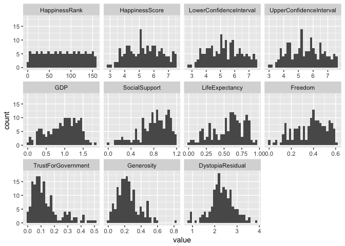

I see Generosity and Dystopia Residual have a shape closer to normal distribution compared to the other factors.

#### Which regions does the dataset use and how many countries are in each region?

```
##
##       Australia and New Zealand      Central and Eastern Europe
##                               2                              29
##                    Eastern Asia     Latin America and Caribbean
##                               6                              24
## Middle East and Northern Africa                   North America
##                              19                               2
##               Southeastern Asia                   Southern Asia
##                               9                               7
##              Sub-Saharan Africa                  Western Europe
##                              38                              21
```

Naturally, the number of countries in each region is quite spread out, so I’ll keep that in mind when plotting.

Now I’ll divide the class based on the quartiles and make a new column called “GDPClass”.

```
## [1] very high very high very high very high very high very high
## Levels: very high high moderate low
```

Next, I’m going to divide the happiness scores into categories, and make a new column called “HappinessClass”.

```
## [1] very high very high very high very high very high very high
## Levels: very high high moderate low
```

## Univariate Analysis

Structure of Dataset

The dataset has 13 variables for 157 countries to measure their happiness scores. The six factors that affect on the happiness scoare is: GDP, Family (Social Support), Health (Life Expectancy), Freedom, Trust, and Generosity.Happiness score goes from 0 (unhappy) to 10 (happy), and other factors increase when their numbers go up.

Main Feature of Interest in the Dataset

What affect people’s happiness? What has greater influence for happiness? My initial assumption is GDP wouldn’t necessary play a big part in happiness — but family support and health would. I’ve also read before that helping others makes you happy, so maybe generosity would be another big factor for happiness. Finding out each factor’s correlation with others would be interesting, too.

## Bivariate Plots Section

#### Regions and Happiness

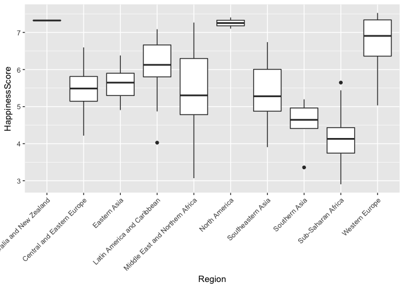

This shows Sub-Saharan Africa has the lowest median as well as the IQR.

#### Relationship between Sosial Support and Life Expectancy

Is life expectancy related to social supportness? I will divide social support column into groups.

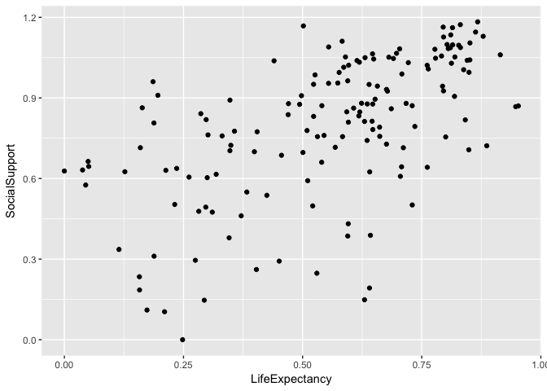

Also based on each region:

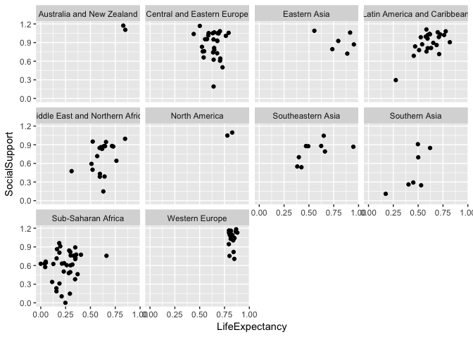

Not so much, although it does get dense towards upper right, the correlation is not strong. People in Sub-Saharan African region are definitely struggling though, compared to the rest of the world…

#### Relationship between Sosial Support and GDP

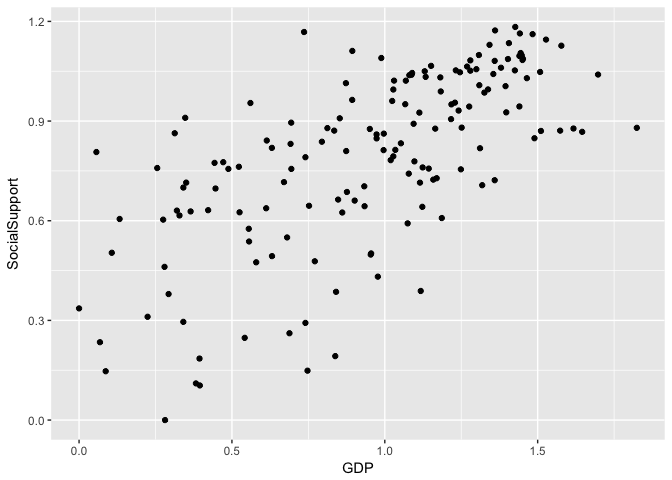

There seems to be some positive relationship between GDP and Social Support. And the density increases as well.

#### Relationship between LifeExpectancy and GDP

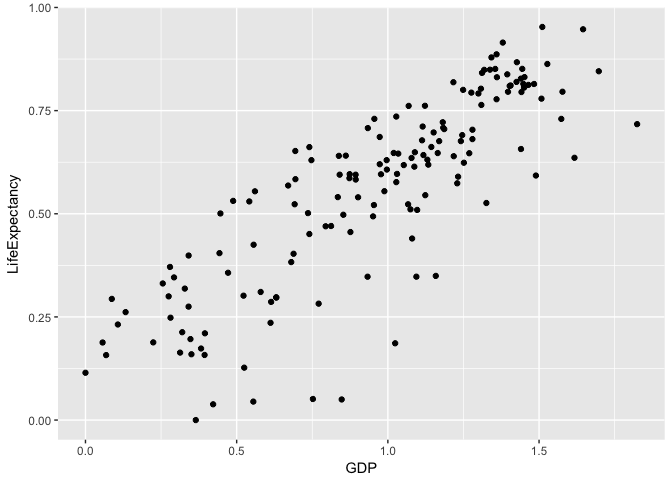

Stronger correlation here.

#### Relationship between Freedom and Trust for Government

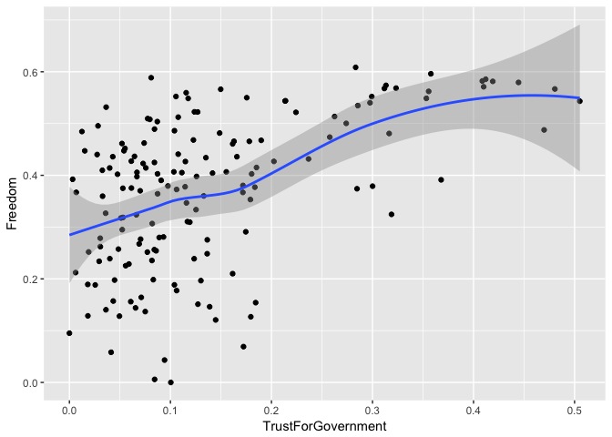

I don’t see a strong correlation here, although it’s not negative. Whether the freedom score is low or high, the majority of the trust scores seems to stay below 0.2.

#### Distribution of factors and Happiness Class

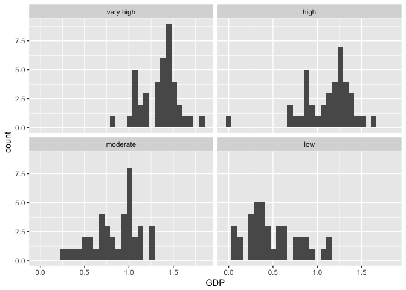

I can clearly see the distributions shifting from high to low, as the happiness goes from high to low.

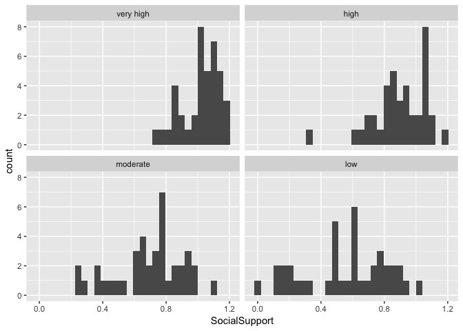

The distribution of very high happiness has smaller variance, while as the happiness score goes down, the variance increases.

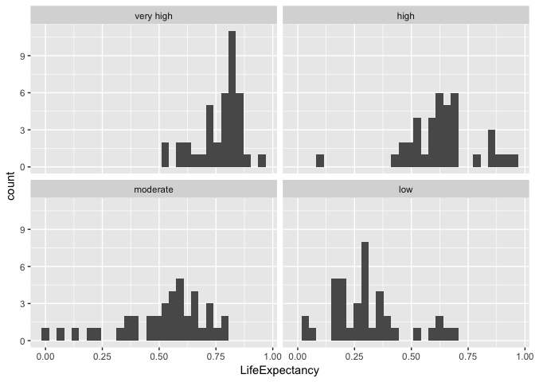

Although less obvious, the shift of distribution does exist based on the happiness categories.

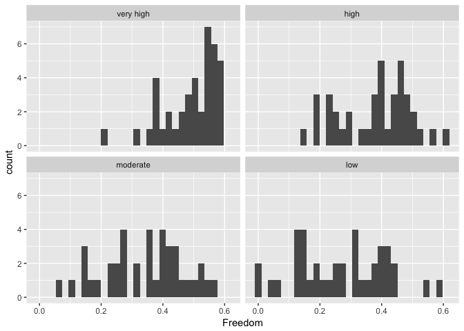

Variance is bigger in Freedom in all distributions.

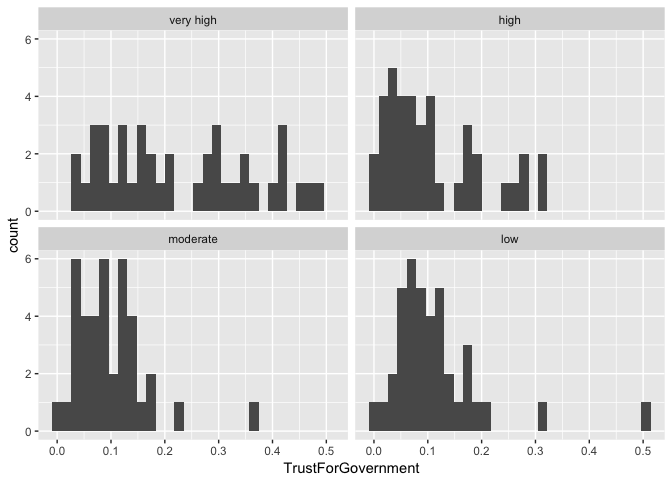

Since the happiest countries’ distribution is so spread out, and trust for their government in the second happiest class is as low as the least happy countries, this confirms that the trust for government doesn’t have much to do with people’s happiness.

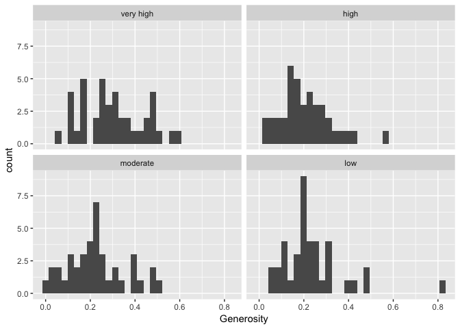

This also confirms the less role of generosity in happiness. By the way, who is it in the “low” class that also appears to be the most generous?

```
##   Country            Region HappinessRank HappinessScore
## 1 Myanmar Southeastern Asia           119          4.395
##   LowerConfidenceInterval UpperConfidenceInterval     GDP SocialSupport
## 1                   4.327                   4.463 0.34112       0.69981
##   LifeExpectancy Freedom TrustForGovernment Generosity DystopiaResidual
## 1         0.3988 0.42692            0.20243    0.81971          1.50655
##   GDPClass HappinessClass
## 1      low            low
```

Myanmar! Now, I just want to see the same plots in density.

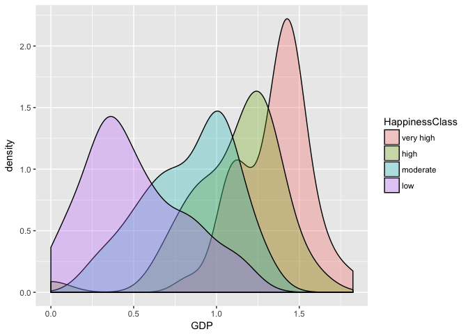

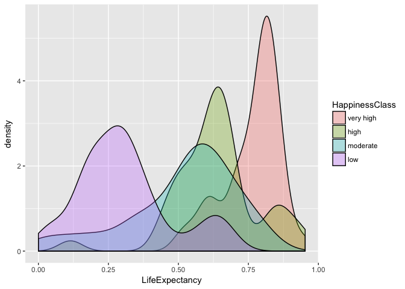

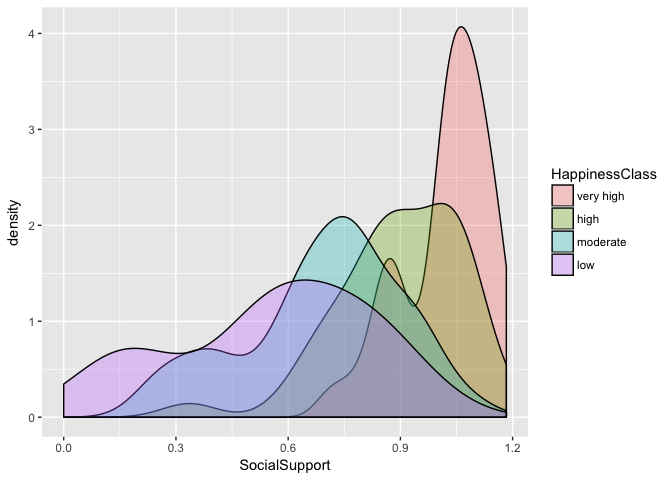

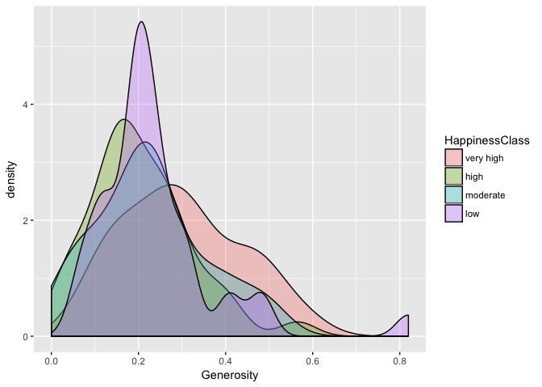

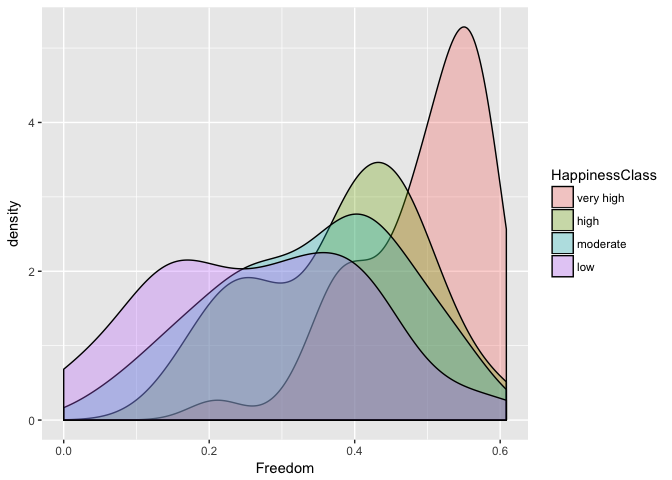

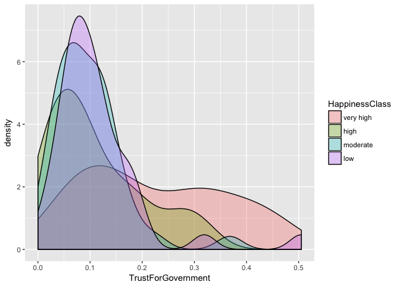

Yep… So GDP can be a big factor to contribute to happiness. Generosity and Trust for Government, on the other hand, not so much. As for the other factors (e.i. Life Expectancy, Social Support, and Freedom), what’s clear is that although ‘high’, ‘moderate’, ‘low’ classes have a lot of overlaps, the ‘very high’ class clearly stands out.

#### Correlation Solution

```
##
##  Pearson's product-moment correlation
##
## data:  Happiness$GDP and Happiness$HappinessScore
## t = 16.059, df = 155, p-value < 2.2e-16
## alternative hypothesis: true correlation is not equal to 0
## 95 percent confidence interval:
##  0.7232138 0.8426452
## sample estimates:
##      cor
## 0.790322
```

```
##
##  Pearson's product-moment correlation
##
## data:  Happiness$LifeExpectancy and Happiness$HappinessScore
## t = 14.806, df = 155, p-value < 2.2e-16
## alternative hypothesis: true correlation is not equal to 0
## 95 percent confidence interval:
##  0.6916693 0.8233164
## sample estimates:
##       cor
## 0.7653843
```

```
##
##  Pearson's product-moment correlation
##
## data:  Happiness$SocialSupport and Happiness$HappinessScore
## t = 13.667, df = 155, p-value < 2.2e-16
## alternative hypothesis: true correlation is not equal to 0
## 95 percent confidence interval:
##  0.6589122 0.8029161
## sample estimates:
##       cor
## 0.7392516
```

```
##
##  Pearson's product-moment correlation
##
## data:  Happiness$Freedom and Happiness$HappinessScore
## t = 8.5659, df = 155, p-value = 1.005e-14
## alternative hypothesis: true correlation is not equal to 0
## 95 percent confidence interval:
##  0.4501564 0.6644688
## sample estimates:
##       cor
## 0.5668267
```

```
##
##  Pearson's product-moment correlation
##
## data:  Happiness$TrustForGovernment and Happiness$HappinessScore
## t = 5.4665, df = 155, p-value = 1.798e-07
## alternative hypothesis: true correlation is not equal to 0
## 95 percent confidence interval:
##  0.2618860 0.5255732
## sample estimates:
##       cor
## 0.4020322
```

```
##
##  Pearson's product-moment correlation
##
## data:  Happiness$Generosity and Happiness$HappinessScore
## t = 1.9772, df = 155, p-value = 0.04979
## alternative hypothesis: true correlation is not equal to 0
## 95 percent confidence interval:
##  0.0002149396 0.3059687867
## sample estimates:
##       cor
## 0.1568478
```

```
##
##  Pearson's product-moment correlation
##
## data:  Happiness$LifeExpectancy and Happiness$GDP
## t = 19.048, df = 155, p-value < 2.2e-16
## alternative hypothesis: true correlation is not equal to 0
## 95 percent confidence interval:
##  0.7831075 0.8785171
## sample estimates:
##       cor
## 0.8370672
```

```
##
##  Pearson's product-moment correlation
##
## data:  Happiness$LifeExpectancy and Happiness$SocialSupport
## t = 9.0593, df = 155, p-value = 5.358e-16
## alternative hypothesis: true correlation is not equal to 0
## 95 percent confidence interval:
##  0.4755681 0.6821467
## sample estimates:
##       cor
## 0.5883768
```

```
##
##  Pearson's product-moment correlation
##
## data:  Happiness$GDP and Happiness$SocialSupport
## t = 11.222, df = 155, p-value < 2.2e-16
## alternative hypothesis: true correlation is not equal to 0
## 95 percent confidence interval:
##  0.5729946 0.7477565
## sample estimates:
##       cor
## 0.6695397
```

I think these numbers confirm my plots: Stronger correlations between happiness with GDP, Life Expectancy, and Social Support. The strongest correlation between each other factor is observed in Life Expecancy and GDP.

#### Comparing rankings of factors

How much of each factor score does it affect the happiness ranking?

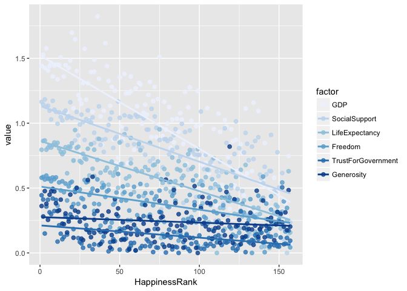

This plot shows some factors display stronger, negative correlation to happiness than the other. However, I can see that some countries have higher GDP while being not so happy, so it would be interesting to see what are causing those results.

## Bivariate Analysis

Observations in This Part of the Investigation

First, I observed relationships between Happiness Score and each factor, as well as the relationships between some of the factors. The variance between the happy regions and unhappy ones are pretty obvious, and I wanted to see what factors were contributing to that result. After dividing the happiness into groups, I’ve compared the distributions of the factors. What was interesting was that there wasn’t a strong relationship between Freedom and Trust for Government like I expected.

The Strongest Relationship of Factors

After comparing the density of factors in each group of happiness, I saw that the GDP had the strongest seperation in the level of happiness, while Generosity and Trust for Government displayed weak relationships with happiness: Being happy does not mean more generous, and perception of government corruption does not seem to affect happiness either. The correlation coefficients also backed up this insight.

## Multivariate Plots Section

#### Happiness and GDP, based on region

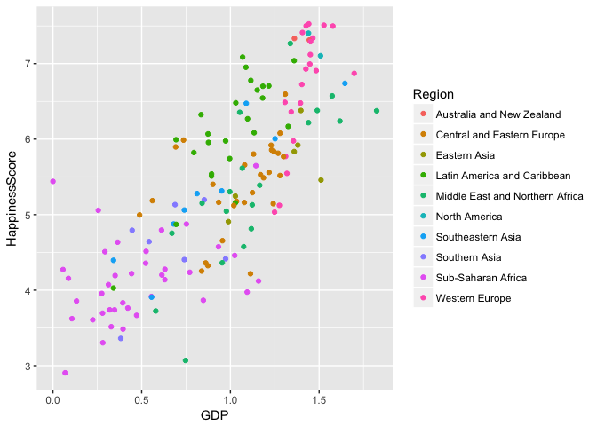

I see that GDP may have a strong influence on the score of happiness: the higher the GDP, the higher their happiness scores tend to be, and the highest and lowest points tend to be grouped by regions, while the midsection is rather scattered in colors.

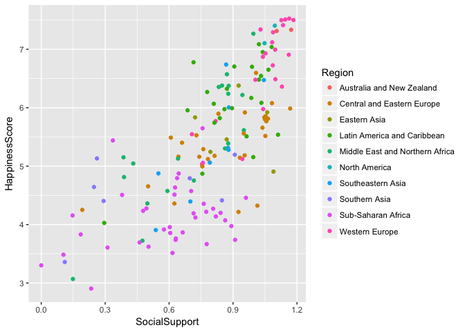

Here, the correlation doesn’t seem as strong as the GDP-Happiness plot, but I can still see a positive correlation. Countries with higher GDPs seem to also have stronger social support.

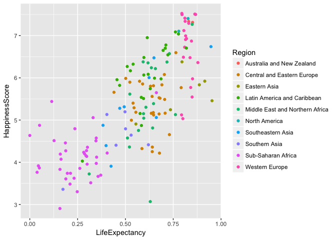

Positive correlation with similar region patterns to the previous two plots, also observing region-wide seperation there.

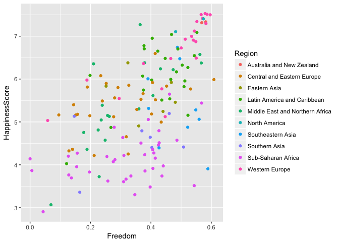

Hmm, this seems pretty scattered. Although I still see the same region colors on the top right corner, the rest of the group doesn’t seem to tell me anything significant: Some countries have high sense of freedom, but not high happiness scores. Colors of regions also seem to be more scattered.

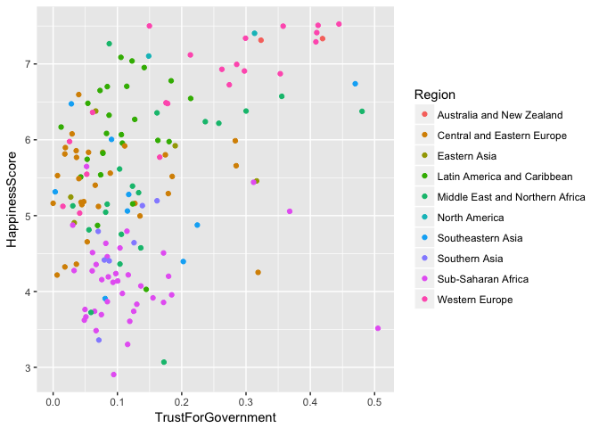

The majority seems to lack their trust in their government, regardless of their happiness.

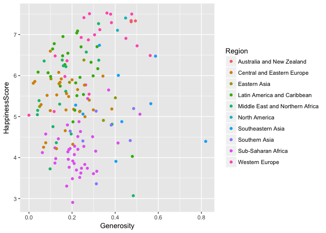

When it comes to generosity, regardless of the region, there is no relationship with happiness.

#### Relationship between Trust and Freedom, based on region

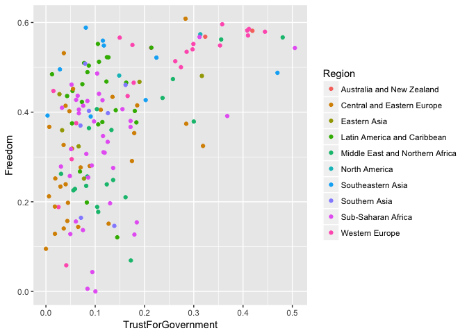

This is interesting. More freedom does not seem to mean more trust in their government.

#### Generosity and Happiness,based on GDP Class

Now, I want to see if GDP would affect people’s generousity, and therefore happines. I’ll compare the relationship between “Generosity” and “Happiness Score” based on “GDP Class”.

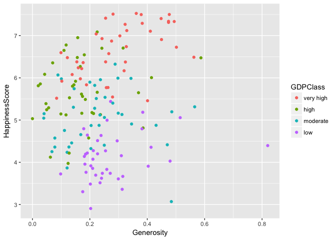

This tells me that higher the GDP does not mean they are more generous, even though it could mean happier. How about social support?

#### SocialSupport and Happiness, based on GDP Class

What is the relationship betwen social supportness and GDP class, and their happiness?

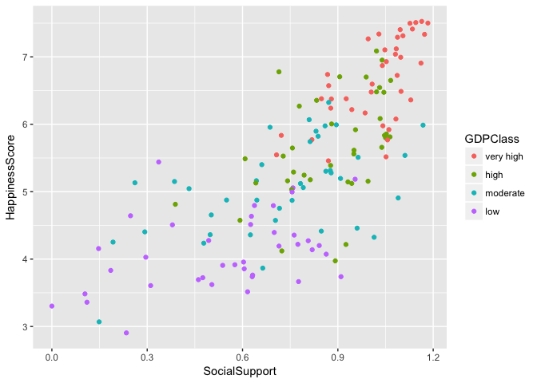

This tells me the higher GDP classes have more social support from their family, and also scoring higher happiness.

#### Life Expectancy and Happiness, based on GDP Class

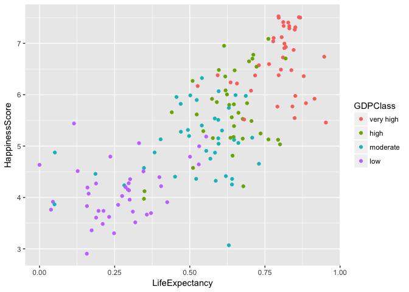

This meets my expectations… the higher the GDP, the higher the life expectancy, and happier people.

## Multivariate Analysis

Observations in This Part of the Investigation

Bivariate plots with stronger correlations also seem to be tied with regions when grouped. When looking at the Happiness Score with Social Support based on GDP class, and then with Life Expectancy based on GDP class, the seperation is easily recognized.

Interesting or Surprising Interactions Between Features

To me it was interesting to see the relationship between GDP and Social Support, resulting in their happiness, while GDP and Life Expectancy seem to have causation more ovious (reference). I don’t see the direct cause and effect between them, and it would be interesting to dig deeper on this subject.